# Pre-processing & Deriving Conditional League Strengths

## Data Overview

The following data was gathered using the `worldfootballR` library to scrape 2019-20 UEFA Champions League group stage and knockout game results and the 2018-19 domestic league results for the 32 competing teams across 16 individual league competitions[^1] from fbref.com.

## Data Pre-processing

In order to use the domestic competition and UEFA Champions League matchup data scraped from [fbref.com](https://www.fbref.com/)[^2] with the Bradley-Terry package, `BradleyTerry2`, the raw data must first be cleaned, parsed, and reformated into the package’s expected format. This code follows that found in Lecture 12 (Deshpande 2025), particularly when refactoring home and away win data into a trainable DataFrame.

```r
# Helper to remove xG columns from relevant leagues so all competitions have the same number of columns
remove_xg = function(df){
  if((df %>% select(contains('_xG')) %>% length()) > 0){
    return(df %>% select(-contains('_xG')))
  }
  else {
    return(df)
  }
}
austria = remove_xg(austria)
belgium = remove_xg(belgium)
croatia = remove_xg(croatia)
czech = remove_xg(czech)
england = remove_xg(england)
france = remove_xg(france)
germany = remove_xg(germany)
greece = remove_xg(greece)
italy = remove_xg(italy)
nether = remove_xg(nether)
portugal = remove_xg(portugal)
russia = remove_xg(russia)
serbia = remove_xg(serbia)
spain = remove_xg(spain)
turkey = remove_xg(turkey)
ukraine = remove_xg(ukraine)
```

```r
# Concatenate all leagues together
all = austria %>%
  rbind(belgium) %>%
  rbind(croatia) %>%
  rbind(czech) %>%
  rbind(england) %>%
  rbind(france) %>%
  rbind(germany) %>%
  rbind(greece) %>%
  rbind(italy) %>%
  rbind(nether) %>%
  rbind(portugal) %>%
  rbind(russia) %>%
  rbind(serbia) %>%
  rbind(spain) %>%
  rbind(turkey) %>%
  rbind(ukraine)
all %>% head(10)
```

| Competition_Name | Gender | Country | Season_End_Year | Round | Wk | Day | Date | Time | Home | HomeGoals | Away | AwayGoals | Attendance | Venue | Referee | Notes | MatchURL |
| --- | --- | --- | --- | --- | --- | --- | --- | --- | --- | --- | --- | --- | --- | --- | --- | --- | --- |
| Austrian Football Bundesliga | M | AUT | 2019 | Regular season | 1 | Fri | 2018-07-27 | 20:45:00 | Austria Wien | 2 | Wacker Innsbr | 1 | 12673 | Generali Arena | Christopher Jäger | NA | https://fbref.com/en/matches/6c36d5e8/Austria-Wien-Wacker-Innsbruck-July-27-2018-Austrian-Bundesliga |
| Austrian Football Bundesliga | M | AUT | 2019 | Regular season | 1 | Sat | 2018-07-28 | 17:00:00 | SCR Altach | 2 | Mattersburg | 3 | 4523 | CASHPOINT Arena | Dieter Muckenhammer | NA | https://fbref.com/en/matches/b5940ee5/Rheindorf-Altach-Mattersburg-July-28-2018-Austrian-Bundesliga |
| Austrian Football Bundesliga | M | AUT | 2019 | Regular season | 1 | Sat | 2018-07-28 | 17:00:00 | Sturm Graz | 3 | Hartberg | 2 | 10785 | Merkur Arena | Rene Eisner | NA | https://fbref.com/en/matches/f54b7835/Sturm-Graz-Hartberg-July-28-2018-Austrian-Bundesliga |
| Austrian Football Bundesliga | M | AUT | 2019 | Regular season | 1 | Sun | 2018-07-29 | 17:00:00 | St. Pölten | 4 | Wolfsberger AC | 3 | 2786 | NV Arena | Robert Schörgenhofer | NA | https://fbref.com/en/matches/44323758/St-Polten-Wolfsberger-AC-July-29-2018-Austrian-Bundesliga |
| Austrian Football Bundesliga | M | AUT | 2019 | Regular season | 1 | Sun | 2018-07-29 | 17:00:00 | Admira | 0 | Rapid Wien | 3 | 5200 | BSFZ-Arena | Alexander Harkam | NA | https://fbref.com/en/matches/9b206c50/Admira-Wacker-Modling-Rapid-Wien-July-29-2018-Austrian-Bundesliga |
| Austrian Football Bundesliga | M | AUT | 2019 | Regular season | 1 | Sun | 2018-07-29 | 17:00:00 | RB Salzburg | 3 | LASK | 1 | 11532 | Red Bull Arena | Harald Lechner | NA | https://fbref.com/en/matches/7704f43d/Red-Bull-Salzburg-LASK-July-29-2018-Austrian-Bundesliga |
| Austrian Football Bundesliga | M | AUT | 2019 | Relegation round | 1 | Sat | 2019-03-30 | 17:00:00 | Hartberg | 0 | Wacker Innsbr | 2 | 4635 | PROfertil ARENA | Stefan Ebner | NA | https://fbref.com/en/matches/ed31c559/Hartberg-Wacker-Innsbruck-March-30-2019-Austrian-Bundesliga |
| Austrian Football Bundesliga | M | AUT | 2019 | Relegation round | 1 | Sat | 2019-03-30 | 17:00:00 | SCR Altach | 2 | Mattersburg | 1 | 4048 | CASHPOINT Arena | Manuel Schüttengruber | NA | https://fbref.com/en/matches/9473e323/Rheindorf-Altach-Mattersburg-March-30-2019-Austrian-Bundesliga |
| Austrian Football Bundesliga | M | AUT | 2019 | Relegation round | 1 | Sat | 2019-03-30 | 17:00:00 | Rapid Wien | 3 | Admira | 0 | 11600 | Allianz Stadion | Rene Eisner | NA | https://fbref.com/en/matches/0cc0fe4a/Rapid-Wien-Admira-Wacker-Modling-March-30-2019-Austrian-Bundesliga |
| Austrian Football Bundesliga | M | AUT | 2019 | Championship round | 1 | Sun | 2019-03-31 | 14:30:00 | Sturm Graz | 0 | St. Pölten | 1 | 8567 | Merkur Arena | Dominik Ouschan | NA | https://fbref.com/en/matches/ea07224c/Sturm-Graz-St-Polten-March-31-2019-Austrian-Bundesliga |

With the leagues all concatenated together, we can check to see the distribution of the complete DataFrame’s members.

| Competition_Name | Gender | Country | Season_End_Year | Round | Wk | Day | Date | Time | Home | HomeGoals | Away | AwayGoals | Attendance | Venue | Referee | Notes | MatchURL |
| --- | --- | --- | --- | --- | --- | --- | --- | --- | --- | --- | --- | --- | --- | --- | --- | --- | --- |
| Eredivisie | M | NED | 2019 | Eredivisie | 17 | Sat | 2018-12-22 | 19:45:00 | NAC Breda | 4 | Heerenveen | 2 | 18352 | Rat Verlegh Stadion | Jochem Kamphuis | NA | https://fbref.com/en/matches/1fc07169/NAC-Breda-Heerenveen-December-22-2018-Eredivisie |
| Ukrainian Premier League | M | UKR | 2019 | Regular season | 20 | Sat | 2019-03-02 | 18:00:00 | Chornomorets | 0 | Shakhtar | 1 | 10125 | Stadion Chornomorets | Ihor Paskhal | NA | https://fbref.com/en/matches/bbff34dc/Chornomorets-Odesa-Shakhtar-Donetsk-March-2-2019-Ukrainian-Premier-League |
| Ligue 1 | M | FRA | 2019 | Ligue 1 | 32 | Sat | 2019-04-13 | 17:00:00 | Marseille | 2 | Nîmes | 1 | 62614 | Orange Vélodrome | Franck Schneider | NA | https://fbref.com/en/matches/10c30fce/Marseille-Nimes-April-13-2019-Ligue-1 |
| Ligue 1 | M | FRA | 2019 | Ligue 1 | 24 | Fri | 2019-02-08 | 20:45:00 | Dijon | 1 | Marseille | 2 | 15095 | Stade Gaston Gérard | Thomas Léonard | NA | https://fbref.com/en/matches/da4a3dd0/Dijon-Marseille-February-8-2019-Ligue-1 |
| Austrian Football Bundesliga | M | AUT | 2019 | Regular season | 18 | Sun | 2018-12-16 | 17:00:00 | Austria Wien | 6 | Rapid Wien | 1 | 16582 | Generali Arena | Harald Lechner | NA | https://fbref.com/en/matches/3af7e4cf/Austria-Wien-Rapid-Wien-December-16-2018-Austrian-Bundesliga |
| Süper Lig | M | TUR | 2019 | NA | 3 | Sun | 2018-08-26 | 19:15:00 | Sivasspor | 0 | Kasımpaşa | 3 | NA | 4 Eylül Stadi | Hüseyin Göçek | NA | https://fbref.com/en/matches/a1e23cb5/Sivasspor-Kasimpasa-August-26-2018-Super-Lig |
| Super League Greece | M | GRE | 2019 | Super League Greece | 21 | Sun | 2019-02-17 | 19:30:00 | Olympiacos | 4 | AEK Athens | 1 | 29010 | Stadio Georgios Karaiskáki | Tobias Stieler | NA | https://fbref.com/en/matches/2179d23b/Olympiacos-AEK-Athens-February-17-2019-Super-League-Greece |
| Ukrainian Premier League | M | UKR | 2019 | Regular season | 5 | Sat | 2018-08-18 | 19:30:00 | Dynamo Kyiv | 1 | FC Oleksandriya | 0 | 11635 | NSK Olimpijs'kyj | Vitalii Romanov | NA | https://fbref.com/en/matches/c224a4f2/Dynamo-Kyiv-FC-Oleksandriya-August-18-2018-Ukrainian-Premier-League |
| Ligue 1 | M | FRA | 2019 | Ligue 1 | 24 | Sun | 2019-02-10 | 17:00:00 | Guingamp | 0 | Lille | 2 | 13886 | Stade du Roudourou | Benoît Bastien | NA | https://fbref.com/en/matches/1ee062ca/Guingamp-Lille-February-10-2019-Ligue-1 |
| Serie A | M | ITA | 2019 | NA | 8 | Sat | 2018-10-06 | 15:00:00 | Cagliari | 2 | Bologna | 0 | 15019 | Sardegna Arena | Fabrizio Pasqua | NA | https://fbref.com/en/matches/e336189b/Cagliari-Bologna-October-6-2018-Serie-A |

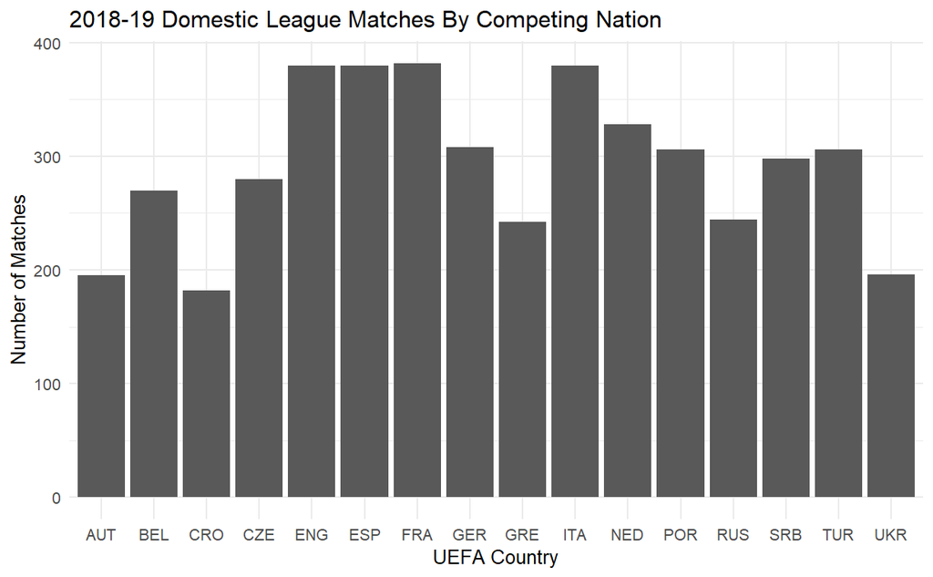

```r
# CODE FROM LECTURE 12
# results <-
#  no_ties |>
#  dplyr::rename(home.team = Home, away.team = Opponent) |>
#  dplyr::group_by(home.team, away.team) |>
#  dplyr::summarise(
#    home.win = sum(Home_Winner),
#    away.win = sum(Opp_Winner), .groups = 'drop') |>
#  dplyr::mutate(
#    home.team = factor(home.team, levels = unik_teams),
#    away.team = factor(away.team,levels = unik_teams))
no_ties = all %>% filter(HomeGoals != AwayGoals) %>%
  filter(!str_detect(Round, "play-offs") | is.na(Round)) %>% ## removing matchups in pro/rel playoffs, otherwise we'll see skewed strengths for those leagues
  mutate(Home_Winner = case_when(HomeGoals > AwayGoals ~ 1, .default=0),
         Opp_Winner = case_when(AwayGoals > HomeGoals ~ 1, .default=0))

unik_teams = sort(unique(c(no_ties$Home, no_ties$Away)))

results = no_ties %>%
  rename(home.team = Home, away.team = Away) %>%
  group_by(home.team, away.team) %>%
  dplyr::summarise(
    home.win = sum(Home_Winner),
    away.win = sum(Opp_Winner), .groups = 'drop') |>
  dplyr::mutate(
    home.team = factor(home.team, levels = unik_teams),
    away.team = factor(away.team, levels = unik_teams))
results[sample(1:nrow(results),size=10),]
```

| home.team | away.team | home.win | away.win |
| --- | --- | --- | --- |
| Sint-Truiden | Zulte Waregem | 1 | 0 |
| Sampdoria | Udinese | 1 | 0 |
| Sparta Prague | Slovácko | 1 | 0 |
| Sint-Truiden | Waas-Beveren | 1 | 0 |
| Dynamo Kyiv | Shakhtar | 1 | 0 |
| Napredak Kruševac | Dinamo Vranje | 1 | 0 |
| Moreirense | Santa Clara | 0 | 1 |
| Sparta Prague | Sigma Olomouc | 1 | 0 |
| Zulte Waregem | Standard Liège | 1 | 0 |
| Cardiff City | West Ham | 1 | 0 |

With the data now in place and formatted for `BradleyTerry2`, we can begin fitting a Bradley-Terry model to determine latent team strength for all clubs competing in the 2019-20 UEFA Champions League group stage based on their domestic league results.